# DS311 - R Lab Assignment

### Question 3

Download the housing data set from www.jaredlander.com and find out what explains the housing prices in New York City.

Note: Check your working directory to make sure that you can download the data into the data folder.

1. Create your own descriptive statistics and aggregation tables to summarize the data set and find any meaningful results between different variables in the data set.

```r
# Head of the cleaned data set
head(housingData)
```

|  | Neighborhood | Market.Value.per.SqFt | Boro | Year.Built |
| --- | --- | --- | --- | --- |
| 1 | FINANCIAL | 200.00 | Manhattan | 1920 |
| 2 | FINANCIAL | 242.76 | Manhattan | 1985 |
| 4 | FINANCIAL | 271.23 | Manhattan | 1930 |
| 5 | TRIBECA | 247.48 | Manhattan | 1985 |
| 6 | TRIBECA | 191.37 | Manhattan | 1986 |
| 7 | TRIBECA | 211.53 | Manhattan | 1985 |

```r
# Enter your code here!
str(housingData)
```

```
## 'data.frame':    2530 obs. of  4 variables:
##  $ Neighborhood         : chr  "FINANCIAL" "FINANCIAL" "FINANCIAL" "TRIBECA" ...
##  $ Market.Value.per.SqFt: num  200 243 271 247 191 ...
##  $ Boro                 : chr  "Manhattan" "Manhattan" "Manhattan" "Manhattan" ...
##  $ Year.Built           : int  1920 1985 1930 1985 1986 1985 1986 1987 1985 1986 ...
##  - attr(*, "na.action")= 'omit' Named int [1:96] 3 1395 1400 1412 1417 1425 1428 1429 1440 1445 ...
##   ..- attr(*, "names")= chr [1:96] "3" "1395" "1400" "1412" ...
```

```r
min(housingData$Market.Value.per.SqFt)
```

```
## [1] 10.66
```

```r
max(housingData$Market.Value.per.SqFt)
```

```
## [1] 399.38
```

```r
print(housingData[housingData$Market.Value.per.SqFt == min(housingData$Market.Value.per.SqFt),3])
```

```
## [1] "Queens"
```

```r
print(housingData[housingData$Market.Value.per.SqFt == max(housingData$Market.Value.per.SqFt),3])
```

```
## [1] "Manhattan"
```

```r
mean(housingData$Market.Value.per.SqFt)
```

```
## [1] 133.1731
```

2. Create multiple plots to demonstrates the correlations between different variables. Remember to label all axes and give title to each graph.

```r
# Enter your code here!
avg <- aggregate(housingData$Market.Value.per.SqFt, list(housingData$Boro), FUN=mean)
avg
```

| Group.1 | x |
| --- | --- |
| Bronx | 47.93232 |
| Brooklyn | 80.13439 |
| Manhattan | 180.59265 |
| Queens | 77.38137 |
| Staten Island | 41.26958 |

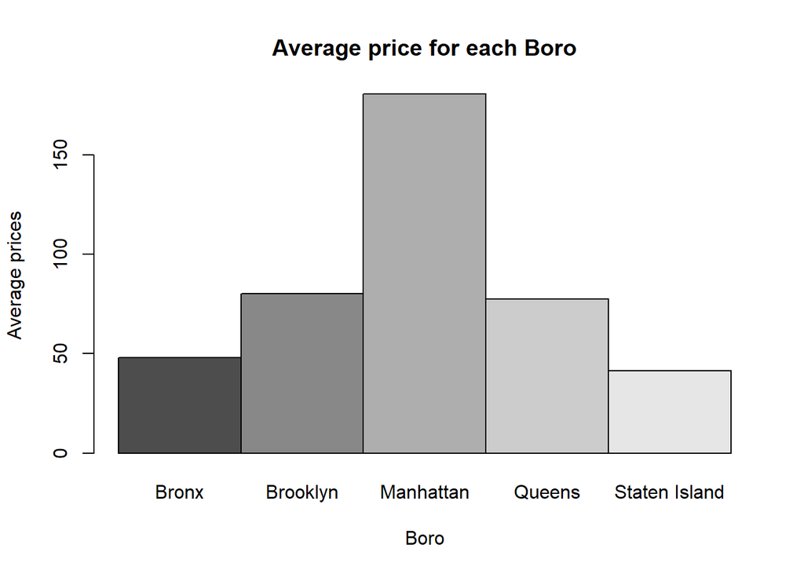

```r
barplot(matrix(avg$x), beside=T, main='Average price for each Boro', names.arg = avg$Group.1, ylab="Average prices", xlab="Boro")
```

3. Write a summary about your findings from this exercise.

In the bar plot, Manhattan is the most expensive average price for the boro.